# 세계 시총 1위 주식을 산다면?

유튜브 채널 '신사임당'에 업로드 된 동영상 중 **'주식투자에 기업분석이 필요없는 이유'**라는 제목의 영상이 있었다.

영상에서는 조던(김장섭)님이 세계 시가총액 1위인 기업의 주식을 사면 기업분석을 하지 않아도 된다고 설명했다.  
이러한 설명의 근거는 **'효율적 시장가설'**이었다.

효율적 시장가설은 **자본시장의 가격은 이용가능한 정보를 충분히 즉각적으로 반영하고 있다는 가설이다.**  
다시말해 우리가 접근할 수 있는 정보는 이미 주식가격에 반영되어 있기 때문에 **시가총액 1위인 기업은 그만한 이유와 가치가 있다는 것이다.**

영상에서는 세계 1등 주식은 평균적으로 연 30%가 오른다고 하고, **시장 벤치마크(S&P500)보다 수익률이 좋다고 한다.** 투자전문가인 펀드매니저 중에서 시장 벤치마크보다 수익률이 좋은 펀드매니저는 10%도 되지 않는다고 한다.  
만약 설명이 맞다면 정말 간단한 방법으로 엄청난 수익률을 얻을 수 있다는 것이다.

이러한 투자전략(이하 'ONLY_ONE 투자전략')을 데이터를 통해 아래의 가설을 확인해보았다.

**가설 : ONLY ONE 투자가 S&P500 지수(벤치마크)에 투자할 때보다 수익률이 더 높을 것이다.**

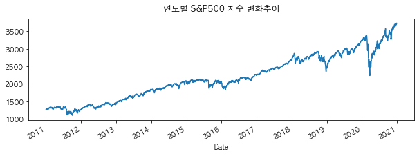

위 그래프는 S&P500의 연도별 지수변화를 나타내고 있다.  
변동성은 있으나 10년간 1271에서 3703으로 2500포인트 가까이 상승하였다.

그렇다면 S&P500 지수에 투자했다면 투자수익률은 어땠을까?  
S&P500 지수를 추종한 'vanguard 500 index fund', 'SPDR S&P 500 Trust ETF' 데이터를 이용하여 확인해보았다.

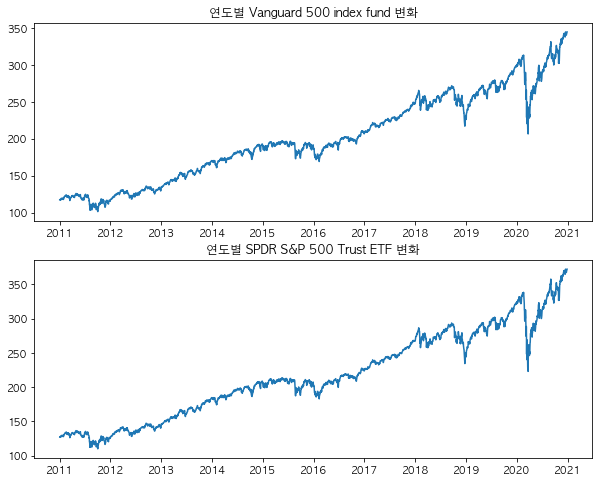

ETF마다 종목별 가중치는 다르겠지만, **같은 S&P500 지수를 추종하기 때문에 가격변화 그래프의 모양이 거의 일치한다.**  
대략 2011년에서 2020년까지 대략 250달러 정도 상승한 것으로 보여진다(10년에 2.5배정도).  
vanguard 500 index fund을 기준으로 수익률을 계산해보았다.

| Date | High | Low | Open | Close | Volume | Adj Close |
| --- | --- | --- | --- | --- | --- | --- |
| 2011-01-03 | 117.129997 | 117.129997 | 117.129997 | 117.129997 | 0.0 | 96.938492 |
| 2011-01-04 | 116.980003 | 116.980003 | 116.980003 | 116.980003 | 0.0 | 96.814346 |
| 2011-01-05 | 117.580002 | 117.580002 | 117.580002 | 117.580002 | 0.0 | 97.310913 |
| 2011-01-06 | 117.379997 | 117.379997 | 117.379997 | 117.379997 | 0.0 | 97.145378 |
| 2011-01-07 | 117.160004 | 117.160004 | 117.160004 | 117.160004 | 0.0 | 96.963326 |

시드머니가 천만원이고 추가 납입은 하지 않는다고 가정한다면, 시드머니가 천만원(2011년 1월 3일, 기준환율 1138.9원)이라면 8780달러로 환전가능하다.  
1월 3일 기준, 시초가는 117.129997 달러로 74개를 구입이 가능하다.

| Date | High | Low | Open | Close | Volume | Adj Close |
| --- | --- | --- | --- | --- | --- | --- |
| 2020-12-21 | 340.839996 | 340.839996 | 340.839996 | 340.839996 | 0.0 | 340.839996 |
| 2020-12-22 | 340.160004 | 340.160004 | 340.160004 | 340.160004 | 0.0 | 340.160004 |
| 2020-12-23 | 340.410004 | 340.410004 | 340.410004 | 340.410004 | 0.0 | 340.410004 |
| 2020-12-24 | 341.649994 | 341.649994 | 341.649994 | 341.649994 | 0.0 | 341.649994 |
| 2020-12-28 | 344.630005 | 344.630005 | 344.630005 | 344.630005 | 0.0 | 344.630005 |

10년 후, 2020년 12월 24일 기준 종가 341.65이므로 10년 전보다 224.5달러 정도 가격이 올라갔다.  
16613달러의 수익을 얻을 수 있었다. **수익률은 189%** 다.

이번에는 ONLY_ONE 투자전략의 수익률을 알아볼 차례이다. 다시한번 ONLY_ONE 투자전략에 대해 설명하자면,

**ONLY_ONE 투자전략**

- 시가총액 1위인 기업의 주식을 연초에 매수한다.
- 1년마다 리밸런싱을 한다.
- 시가총액 1위인 기업이 바뀐다면 사놓은 주식을 매도하고, 새로운 1위 주식을 매수한다.

간단하다. **계속해서 시가총액 1위인 기업주식만 가지고 있으면 된다.** 계속해서 차트를 살펴볼 필요도 없다.  
일년에 한번씩 시가총액 순위만 확인하면 끝이다.

|  | 연도 | 시총1위 |
| --- | --- | --- |
| 10 | 2010 | Exxon Mobil |
| 9 | 2011 | PetroChina |
| 8 | 2012 | Exxon Mobil |
| 7 | 2013 | Exxon Mobil |
| 6 | 2014 | Apple Inc. |
| 5 | 2015 | Apple Inc. |
| 4 | 2016 | Apple Inc. |
| 3 | 2017 | Apple Inc. |
| 2 | 2018 | Apple Inc. |
| 1 | 2019 | Apple Inc. |
| 0 | 2020 | Microsoft |

위에 있는 표는 2011년부터 2020년까지 시총 1위 기업을 나타낸 표이다.  
PetroChina는 상하이거래소에 상장된 회사 데이터를 구하지 못해 직전 연도 시총 1위 회사로 대체하였다.  
수익률을 계산하기 전, 각 기업의 연도별 주가 변화추이를 알아보았다.

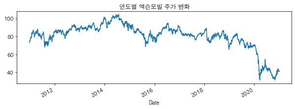

2011년, 2012년 시총 1위 엑슨모빌(Exxon Mobil)의 연도별 주가 변화를 보여주는 그래프이다.  
엑슨모빌은 석유회사이다. 원유가격의 변동이 회사의 매출에 큰 영향을 주기때문에 주가의 변동성이 심한 것으로 보인다.  
2014년까지 상승하다가 2015년 부터 주가가 하락하고 있다. 특히 2020년은 '코로나19 + 저유가쇼크'의 영향으로 급격한 감소를 보이고 있다.

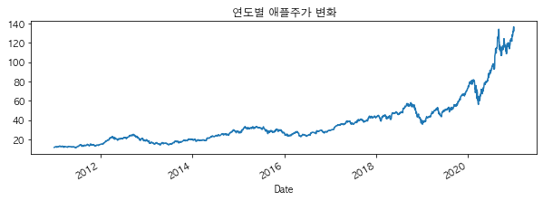

이번에는 애플(APPLE)의 주가변화 그래프이다. 우리가 잘 아는 '애플' 맞다.  
아이폰, 아이패드의 감성만큼이나 아름답게 주가 그래프 또한 '우상향'하는 모습을 보여주고 있다.

각각의 그래프를 살펴보며 시총 1위 기업이라도 주가가 계속 우상향하는 것은 아니라는 것을 알 수 있었다.

만약 엑슨모빌 주식을 사서 2020년까지 기다렸다면, 투자금은 최고점 대비 반토막 났다.  
**ONLY_ONE 투자전략은 일년마다 시총1위 기업으로 리밸런싱하기 때문에 이러한(반토막 날 수 있는) 리스크를 줄여주는 효과가 있다.**

이제 ONLY_ONE 투자전략의 수익률을 알아보자!  
S&P500 지수를 추종하는 ETF 수익률을 계산할 때와 상황은 동일하다. 시드머니는 8780달러이다.

|  | 연도 | 시총1위 |
| --- | --- | --- |
| 10 | 2010 | Exxon Mobil |
| 9 | 2011 | Exxon Mobil |
| 8 | 2012 | Exxon Mobil |
| 7 | 2013 | Exxon Mobil |
| 6 | 2014 | Apple Inc. |
| 5 | 2015 | Apple Inc. |
| 4 | 2016 | Apple Inc. |
| 3 | 2017 | Apple Inc. |
| 2 | 2018 | Apple Inc. |
| 1 | 2019 | Apple Inc. |
| 0 | 2020 | Microsoft |

- 위의 표는 연도별 시가총액 1위 기업을 나타내고 있다.

| Date | Close | Open | High | Low | Volume | Change |
| --- | --- | --- | --- | --- | --- | --- |
| 2010-12-31 | 73.12 | 73.16 | 73.51 | 73.02 | 15270000.0 | -0.0033 |

2011년, 2012년, 2013년 시총 1위는 '엑슨모빌'이다. 2010년 12월 31일 기준, 시초가는 73.16달러로 120주를 구입할 수 있다.  
2012년, 2013년에도 1위는 엑슨모빌이기 때문에 리밸런싱하지 않는다.

2014년, 시총 1위는 '애플'이다. 그렇다면 '엑슨모빌'을 주식을 팔아 투자금을 회수하고 다시 그 돈으로 '애플' 주식을 사야한다.

| Date | Close | Open | High | Low | Volume | Change |
| --- | --- | --- | --- | --- | --- | --- |
| 2014-12-31 | 92.45 | 92.42 | 93.13 | 92.06 | 11340000.0 | -0.0061 |

- '엑슨모빌' 주가를 나타내는 표

| Date | Close | Open | High | Low | Volume | Change |
| --- | --- | --- | --- | --- | --- | --- |
| 2015-01-02 | 27.33 | 27.85 | 27.86 | 26.84 | 212820000.0 | -0.0094 |

- '애플' 주가를 나타내는 표

2014년 12월31일 기준, '엑슨모빌'의 시초가는 92.42달러로 판매하여 11090.4달러를 회수하였고, 애플주식을 398주를 구입하였다.  
2019년 4분기 시총 1위는 여전히 '애플'이기 때문에 더 이상 리밸런싱을 진행하지 않는다.

2020년 말, '애플'주식을 매도하고 투자금을 회수한다.

| Date | Close | Open | High | Low | Volume | Change |
| --- | --- | --- | --- | --- | --- | --- |
| 2020-12-31 | 132.69 | 134.08 | 134.74 | 131.72 | 99120000.0 | -0.0077 |

마지막으로 2020년 12월 31일에 애플 주식을 매도하였다. 31일 기준 종가는 132.69달러로 52811 달러를 회수하였다.

ONLY_ONE 투자전략으로 10년동안 투자를 진행하였다. 그 결과 투자금 8780달러가 52811 달러로 불어났다.

**수익률은 501%이다. S&P500지수 투자수익률(189%)보다 월등히 높은 수익률인 것을 확인할 수 있었다.**

ONLY_ONE 투자전략의 수익률이 S&P500 지수 투자수익률이 높다는 것을 확인하였다.

이번에는 ONLY_ONE 투자전략에서 **리밸런싱 주기를 분기로 하여 분석해보았다.**

똑같이 초기 투자금은 8780 달러이다.

|  | 1분기 | 2분기 | 3분기 | 4분기 | 연도 |
| --- | --- | --- | --- | --- | --- |
| 0 | Exxon Mobil | Exxon Mobil | Exxon Mobil | Exxon Mobil | 2010 |
| 1 | Exxon Mobil | Exxon Mobil | Exxon Mobil | Exxon Mobil | 2011 |
| 2 | Exxon Mobil | Exxon Mobil | Exxon Mobil | Exxon Mobil | 2012 |
| 3 | Exxon Mobil | Exxon Mobil | Apple Inc. | Exxon Mobil | 2013 |
| 4 | Apple Inc. | Apple Inc. | Apple Inc. | Apple Inc. | 2014 |
| 5 | Apple Inc. | Exxon Mobil | Apple Inc. | Apple Inc. | 2015 |
| 6 | Apple Inc. | Apple Inc. | Apple Inc. | Apple Inc. | 2016 |
| 7 | Apple Inc. | Apple Inc. | Apple Inc. | Apple Inc. | 2017 |
| 8 | Apple Inc. | Apple Inc. | Apple Inc. | Apple Inc. | 2018 |
| 9 | Apple Inc. | Apple Inc. | Apple Inc. | Apple Inc. | 2019 |
| 10 | Apple Inc. | Apple Inc. | Apple Inc. | Microsoft | 2020 |

- PetroChina를 Exxon Mobil로 대체한 데이터 프레임

| Date | Close | Open | High | Low | Volume | Change |
| --- | --- | --- | --- | --- | --- | --- |
| 2010-12-31 | 73.12 | 73.16 | 73.51 | 73.02 | 15270000.0 | -0.0033 |

- Exxon Mobil 주가 데이터

2013년 2분기까지 시총 1위는 쭉 '엑슨모빌'이기 때문에 리밸런싱하지 않았다.

2013년 3분기 말 기준, 시가총액 1위는 '애플'이기 때문에 '엑슨모빌'주식을 팔고 '애플'주식으로 갈아탄다.

| Date | Close | Open | High | Low | Volume | Change |
| --- | --- | --- | --- | --- | --- | --- |
| 2013-09-30 | 86.04 | 86.06 | 86.7 | 85.61 | 17490000.0 | -0.0099 |

| Date | Close | Open | High | Low | Volume | Change |
| --- | --- | --- | --- | --- | --- | --- |
| 2013-09-30 | 17.03 | 17.04 | 17.2 | 16.94 | 260160000.0 | -0.0122 |

다음 분기에 다시 시총 1위가 엑슨모빌로 바뀌어 리밸런싱을 진행하였다.

| Date | Close | Open | High | Low | Volume | Change |
| --- | --- | --- | --- | --- | --- | --- |
| 2013-12-31 | 20.04 | 19.79 | 20.05 | 19.79 | 223280000.0 | 0.0121 |

- 2013-12-31 기준, 'Apple' 주가 데이터

| Date | Close | Open | High | Low | Volume | Change |
| --- | --- | --- | --- | --- | --- | --- |
| 2013-12-31 | 101.2 | 100.49 | 101.39 | 100.43 | 8510000.0 | 0.0089 |

- 2013-12-31 기준, 'Exxon Mobil' 주가 데이터

2013년 12월 31일 기준, '애플'의 시초가 19.79달러로 매도하여 '엑슨모빌' 118주를 매수하였다.

다음 분기에 다시 시총 1위가 '애플'로 바뀌어 리밸런싱을 진행하였다.

| Date | Close | Open | High | Low | Volume | Change |
| --- | --- | --- | --- | --- | --- | --- |
| 2014-01-31 | 92.16 | 92.85 | 93.28 | 91.7 | 17370000.0 | -0.0195 |

- 2014-01-31 기준, 'Exxon Mobil' 주가 데이터

| Date | Close | Open | High | Low | Volume | Change |
| --- | --- | --- | --- | --- | --- | --- |
| 2014-01-31 | 17.88 | 17.68 | 17.91 | 17.63 | 465350000.0 | 0.0017 |

- 2014-01-31 기준, 'Apple' 주가 데이터

2015년 1분기까지 쭉 '애플'이 시초 1위기 때문에 리밸런싱을 진행하지 않는다.

2015년 2분기 말, 다시 '엑슨모빌'이 시총 1위가 된다.

| Date | Close | Open | High | Low | Volume | Change |
| --- | --- | --- | --- | --- | --- | --- |
| 2015-06-30 | 31.36 | 31.39 | 31.53 | 31.21 | 177480000.0 | 0.0074 |

- 2015-06-30 기준, 'Apple' 주가 데이터

| Date | Close | Open | High | Low | Volume | Change |
| --- | --- | --- | --- | --- | --- | --- |
| 2015-06-30 | 83.2 | 83.74 | 84.9 | 82.8 | 14980000.0 | 0.0046 |

- 2015-06-30 기준, 'Exxon Mobil' 주가 데이터

2015년 06월 30일 기준, '애플'의 시초가 31.39달러로 매도하여 '엑슨모빌' 230주를 매수하였다.

다음 분기 다시 '애플'이 시가총액 1위가 된다. 또 리밸런싱..

| Date | Close | Open | High | Low | Volume | Change |
| --- | --- | --- | --- | --- | --- | --- |
| 2015-09-30 | 74.35 | 73.4 | 74.35 | 73.33 | 18180000.0 | 0.0189 |

- 2015-09-30 기준, 'Exxon Mobil' 주가 데이터

| Date | Close | Open | High | Low | Volume | Change |
| --- | --- | --- | --- | --- | --- | --- |
| 2015-09-30 | 27.57 | 27.54 | 27.89 | 27.18 | 265890000.0 | 0.011 |

- 2015-09-30 기준, 'Apple' 주가 데이터

2015년 09월 30일 기준, '엑슨모빌'의 시초가 73.4달러로 매도하여 '애플' 612주를 매수하였다.

2020년 3분기까지 시총 1위는 여전히 '애플'이기 때문에 더 이상 리밸런싱을 진행하지 않는다.

| Date | Close | Open | High | Low | Volume | Change |
| --- | --- | --- | --- | --- | --- | --- |
| 2020-12-31 | 132.69 | 134.08 | 134.74 | 131.72 | 99120000.0 | -0.0077 |

- 2020-12-31 기준, 'Apple' 주가 데이터

마지막으로 2020년 12월 31일에 애플 주식을 매도하였다. 31일 기준 종가는 132.69달러로 81206 달러를 회수하였다.

ONLY_ONE 분기별 리밸런싱 투자전략으로 10년동안 투자를 진행하였다. 그 결과 투자금 8780달러가 81206 달러로 불어났다.

**수익률은 825%이다. 매년 리밸런싱하는 것보다 더 높은 수익률인 것을 확인할 수 있었다.**

**추가적으로 처음부터(2010년 12월 31일) '애플' 주식을 샀다면, 어떨까?**

| Date | Close | Open | High | Low | Volume | Change |
| --- | --- | --- | --- | --- | --- | --- |
| 2010-12-31 | 11.52 | 11.53 | 11.55 | 11.48 | 193660000.0 | -0.0035 |
| 2011-01-03 | 11.77 | 11.63 | 11.79 | 11.60 | 445120000.0 | 0.0217 |
| 2011-01-04 | 11.83 | 11.87 | 11.87 | 11.72 | 309350000.0 | 0.0051 |
| 2011-01-05 | 11.93 | 11.77 | 11.94 | 11.77 | 255520000.0 | 0.0085 |
| 2011-01-06 | 11.92 | 11.95 | 11.97 | 11.89 | 300430000.0 | -0.0008 |
| ... | ... | ... | ... | ... | ... | ... |
| 2020-12-24 | 131.97 | 131.32 | 133.46 | 131.10 | 54930000.0 | 0.0077 |
| 2020-12-28 | 136.69 | 133.99 | 137.34 | 133.52 | 124490000.0 | 0.0358 |
| 2020-12-29 | 134.87 | 138.05 | 138.78 | 134.36 | 121050000.0 | -0.0133 |
| 2020-12-30 | 133.72 | 135.71 | 135.96 | 133.40 | 96450000.0 | -0.0085 |
| 2020-12-31 | 132.69 | 134.08 | 134.74 | 131.72 | 99120000.0 | -0.0077 |

2518 rows × 6 columns

- 'Apple' 주가 데이터

2010년 12월 31일 기준, '애플'의 시초가는 11.53달러이다. 초기자금 8780달러로 761주를 매수하였다.

2020년 12월 31일 기준, '애플'의 종가는 132.69달러이다. 전량 매도할 시 100977달러를 회수할 수 있다.

**수익률은 1050%이다.**

리밸런싱 필요없이 처음부터 '애플'만 갖고 있었다면 제일 많은 수익을 얻었을 것이다.

그렇다면 'ONLY_ONE' 투자전략은 쓸모 없는 것일까? **그렇지 않다.**

과연 2010년으로 돌아간다면 자신있게 '애플' 주식을 살 수 있었을까? 자신있게 대답하지 못할 것이다.

엄청나게 다양한 기업이 있고, 하나의 기업이 여러가지 사업을 진행하고 있다.

그러한 것들을 전부 알아보고 미래의 '성장성'까지 고려하여 종목을 선정한다면 엄청난 에너지 소모가 발생한다.

또한 신중하게 내린 판단이 틀렸을 가능성도 존재한다.

그렇기 때문에 **'ONLY_ONE' 투자 전략은 '효율성'측면에서 유용한 전략이라 생각한다.**

종목선정에 힘을 쓸 필요도 없다. 매분기, 매년마다 리밸런싱만 하면 된다. 이렇게 속편한 투자법이 어디 있을까?